# TensorFlow - tf.random_uniform - Explicación y ejemplos

La finalidad de este documento es explicar y ejemplificar los usos de la función "random_uniform", provista en la librería de [TensorFlow](https://www.tensorflow.org/), para Python.

Dicha función es utilizada para generar un tensor con valores aleatorios, que siguen una [distribución uniforme](https://es.wikipedia.org/wiki/Distribuci%C3%B3n_uniforme_continua) entre dos valores conocidos.

El rango de valores posibles es `[minval, maxval)`, donde `minval` queda dentro del rango, y `maxval` queda excluido del mismo.

El significado de esto, con poco nivel de detalle, es que los valores generados se encuentran dentro del rango especificado, y todos los valores tienen la misma **probabilidad** de ser elegidos. Esto puede quedar mejor explicado con los ejemplos del final del documento.

## Argumentos

tf.random_uniform(shape, minval=0, maxval=None, dtype=tf.float32, seed=None, name=None)

Los argumentos de la función son:

- **`shape`**: Las dimensiones del tensor de salida. Se puede pasar a la función como un tensor 1-D de números entros, o como una lista de Python de números enteros. Este es el único argumento requerido de la función, los demás son opcionales.
- **`minval`** [ Valor predeterminado: **minval = 0** ] : El límite inferior del rango de números del que serán generados los valores. Se puede pasar a la función como un tensor 0-D, o un valor de Python, de tipo **`dtype`**.
- **`maxval`** [ Valor predeterminado: **maxval = 1** ] : El límite superior del rango de números del que serán generados los valores. Se puede pasar a la función como un tensor 0-D, o un valor de Python, de tipo **`dtype`**. Si **`dtype`** es **`float32`** o **`float64`**, su valor por default es de 1, si no, se debe especificar su valor explicitamente.
- **`dtype`** [ Valor predeterminado: **dtype = tf.float32** ] : El tipo de valores que quiero generar. Puede ser **`float32`**, **`float64`**, **`int32`**, o **`int64`**.
- **`seed`** [ Valor predeterminado: **seed = None** ] : Un número entero de Python. Es el generador de numeros aleatorios. Se utiliza para que sucesivas ejecuciones del programa generen siempre los mismos valores aleatorios, en el mismo orden. Es util cuando se esta depurando el programa, pero no se recomienda utilizarlo cuando el programa esta terminado.
- **`name`** [ Valor predeterminado: **name = None** ] : El nombre de la operación. Lo utiliza TensorFlow para identificar distintas operaciones dentro del mismo programa. Se pasa a la función como una cadena de texto de Python.

## Ejemplos de uso

```python
import tensorflow as tf
import matplotlib.pyplot as plt
import numpy as np
%matplotlib inline
```

El ejemplo de uso más básico es el de utilizar la funcion con todos los parametros con valores predeterminados. De esta forma estamos creando un tensor de números aleatorios, cuyos valores se encuentran en el rango **`[0, 1)`**, son de tipo **`float32`**, y siguen una distribución uniforme. Se ejemplificará además, el uso del atributo **`name`**.

```python
# Creación de un tensor de 2 x 3, con una lista de Python de números enteros
tensor_uniforme_1 = tf.random_uniform([2, 3])

# Creación de un tensor de 4 x 2, con un tensor de números enteros
tensor = tf.constant([4, 2])
tensor_uniforme_2 = tf.random_uniform(tensor, name="nombre_ejemplo")

# Visualización de los tensores creados
print("Tensor 1: {}".format(tensor_uniforme_1))
print("Tensor 2: {}".format(tensor_uniforme_2))
```

```
Tensor 1: Tensor("random_uniform:0", shape=(2, 3), dtype=float32)
Tensor 2: Tensor("nombre_ejemplo:0", shape=(4, 2), dtype=float32)
```

Como se puede ver, los objetos creados con la función **`tf.random_uniform`**, son tensores de tipo **`float32`**, y dimensiones (2, 3) y (4, 2), respectivamente. Además se puede ver el nombre de cada tensor. Cuando no se especifico el atributo **`name`**, el tensor obtuvo su nombre de la función que lo creó. Cuando se especifica un nombre, el tensor lo adquiere como identidificación.

Los tensores actualmente no contienen ningun valor, para generar los mismos se deben correr los mismos en una Session de TensorFlow.

```python
# Generación de los valores aleatorios
with tf.Session() as sess:
    tensor_uniforme_1 = sess.run(tensor_uniforme_1)
    tensor_uniforme_2 = sess.run(tensor_uniforme_2)

# Impresión de los resultados
print("Tensor con valores aleatorios N° 1: (shape={})".format(tensor_uniforme_1.shape))
print(tensor_uniforme_1)
print()
print("Tensor con valores aleatorios N° 2: (shape={})".format(tensor_uniforme_2.shape))
print(tensor_uniforme_2)
```

```
Tensor con valores aleatorios N° 1: (shape=(2, 3))
[[ 0.88433671  0.43399143  0.8245362 ]
 [ 0.57805014  0.70814478  0.46297073]]

Tensor con valores aleatorios N° 2: (shape=(4, 2))
[[ 0.15313113  0.45295012]
 [ 0.19347596  0.48213005]
 [ 0.82474518  0.5730741 ]
 [ 0.03128076  0.49828649]]
```

Como se puede observar, al no haber especificado un rango de valores, la función utilizó los valores predeterminados de **`minval`** y **`maxval`**. Se puede ver cómo todos los valores generados están ubicados en dicho rango. Sin embargo para visualizar efectivamente la distribición uniforme que siguen los mismos, es necesario generar más valores, para que la cantidad sea significativa.

### Observando la distribución de los valores

Para comprender mejor la distribucion uniforme que siguen los valores generados, se graficarán en un [histograma](https://es.wikipedia.org/wiki/Histograma) de 10 clases, los valores generados en 2 tensores con 100 y 1000 números, respectivamente. Además se especificarán los atributos **`minval`** y **`maxval`**, en uno de los tensores, para ejemplificar su uso.

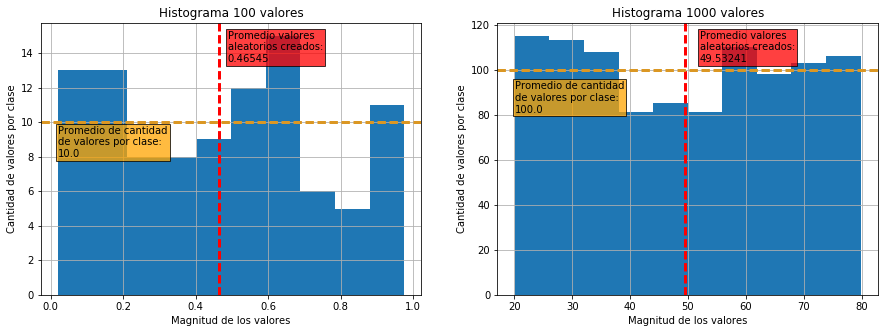

```python
# Creación de ambos tensores
tensor_100 = tf.random_uniform([100])
tensor_1000 = tf.random_uniform([1000], minval=20, maxval=80)

# Generación de los valores aleatorios
with tf.Session() as sess:
    tensor_100 = sess.run(tensor_100)
    tensor_1000 = sess.run(tensor_1000)

# Importación de función de ayuda
from histogram_plots import histograms_x2
histograms_x2(tensor_100, tensor_1000)
```

Como se puede ver en los gráficos, los valores generados, se distribuyen casi uniformemente en todo el rango `[minval, maxval)`. Al aumentar la cantidad de valores generados nos acercamos todavía más a la distribución uniforme teórica. Esto significa que se generan aproximadamente la misma cantidad de valores, en toda la longitud del rango.

Las figuras muestran además, que el promedio de los valores aleatorios creados, está muy cerca del centro del rango utilizado. Esto es otra muestra del comportamiento uniforme de la población de números generados.